# Apple Data

David Su

```r
rm(list=ls())

library(magrittr)
suppressPackageStartupMessages(library(fpp2))
library(forecast)
suppressPackageStartupMessages(library(tseries))
suppressPackageStartupMessages(library(dynlm))
suppressPackageStartupMessages(library(strucchange))
suppressPackageStartupMessages(library(vars))
suppressPackageStartupMessages(library(Hmisc))
```

# I. (5%) Introduction (describe the data, provide some background on the topic, etc.).

2. (80%) Results (answers and plots).

*(a) Produce a time-series plot of your data including the respective ACF and PACF plots.*

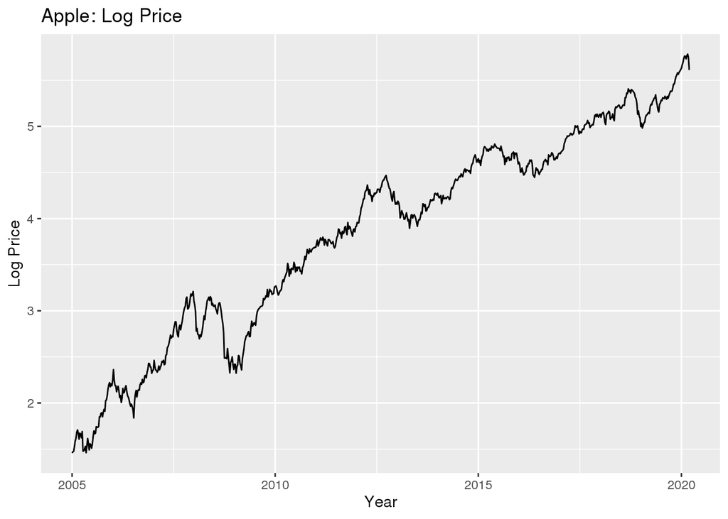

```r
file=read.csv("AAPL_weekly.csv",header = T)$Adj.Close[1257:2047]
Apple=ts(file,start=c(2005,1,3),freq=52)# start August 18 2004
lApple=log(Apple)
autoplot(lApple, main='Apple: Log Price', xlab='Year', ylab='Log Price')
```

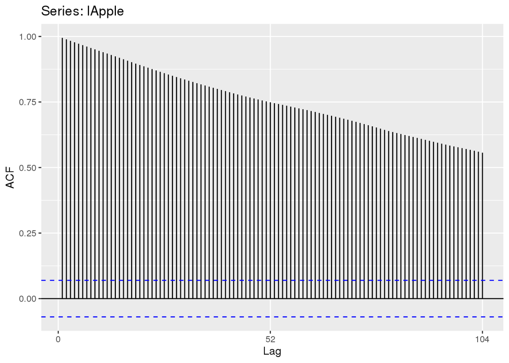

```r
ggAcf(lApple)
```

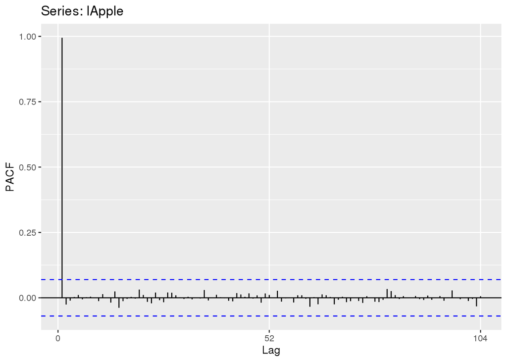

```r
ggPacf(lApple)
```

*(b) Fit a model that includes, trend, seasonality and cyclical components. Make sure to discuss your model in detail.*

```r
lApple.mod2=Arima(lApple,order=c(2,1,2),include.drift=T,xreg=seasonaldummy(lApple))
summary(lApple.mod2)
```

```
## Series: lApple
## Regression with ARIMA(2,1,2) errors
##
## Coefficients:
##          ar1      ar2     ma1     ma2   drift       S1      S2       S3
##       1.7029  -0.8009  -1.685  0.7955  0.0053  -0.0051  0.0049  -0.0256
## s.e.  0.4123   0.3771   0.412  0.3642  0.0017   0.0110  0.0153   0.0187
##            S4       S5       S6       S7       S8       S9      S10      S11
##       -0.0484  -0.0397  -0.0462  -0.0314  -0.0289  -0.0294  -0.0388  -0.0297
## s.e.   0.0216   0.0242   0.0265   0.0286   0.0306   0.0324   0.0340   0.0355
##           S12      S13     S14      S15      S16      S17     S18      S19
##       -0.0322  -0.0101  0.0006  -0.0205  -0.0176  -0.0061  0.0086  -0.0120
## s.e.   0.0368   0.0380  0.0391   0.0400   0.0408   0.0416  0.0422   0.0427
##           S20      S21     S22      S23      S24      S25      S26      S27
##       -0.0015  -0.0124  0.0018  -0.0007  -0.0183  -0.0153  -0.0341  -0.0364
## s.e.   0.0431   0.0435  0.0438   0.0441   0.0442   0.0443   0.0444   0.0444
##           S28      S29     S30      S31     S32     S33     S34     S35     S36
##       -0.0249  -0.0056  0.0092  -0.0005  0.0031  0.0056  0.0190  0.0198  0.0228
## s.e.   0.0443   0.0442  0.0440   0.0438  0.0435  0.0431  0.0426  0.0421  0.0414
##          S37     S38     S39     S40     S41     S42     S43     S44     S45
##       0.0258  0.0281  0.0388  0.0002  0.0029  0.0217  0.0210  0.0349  0.0253
## s.e.  0.0406  0.0398  0.0387  0.0376  0.0363  0.0348  0.0332  0.0314  0.0294
##          S46     S47     S48     S49     S50     S51
##       0.0173  0.0124  0.0294  0.0323  0.0211  -0.004
## s.e.  0.0272  0.0248  0.0221  0.0191  0.0156   0.011
##
## sigma^2 estimated as 0.001999:  log likelihood=1363.02
## AIC=-2612.03   AICc=-2603   BIC=-2345.73
##
## Training set error measures:
##                         ME      RMSE        MAE         MPE     MAPE       MASE
## Training set -1.879321e-05 0.0430704 0.03266813 0.004138133 1.017477 0.09139787
##                      ACF1
## Training set -0.005770246
```

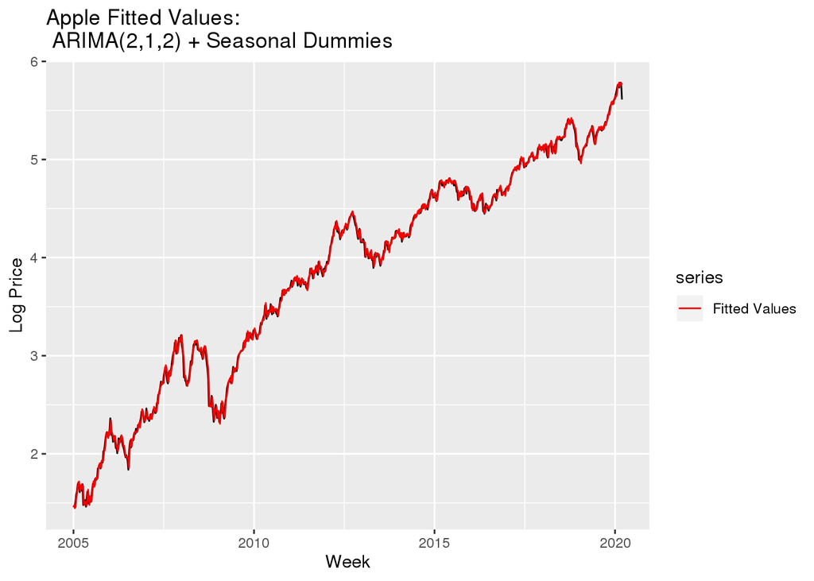

```r
autoplot(lApple,main='Apple Fitted Values:\n ARIMA(2,1,2) + Seasonal Dummies')+
  autolayer(lApple.mod2$fit,series='Fitted Values')+
  xlab('Week')+ylab('Log Price')+
  scale_color_manual(values=c('red'),#,'blue'),
                     breaks=c('Fitted Values'))#,'Forecast'))
```

This model forecasts the log Apple stock prices. It uses an $ARMA(2,2)$ to model the cycle. The $I(1)$ with drift part of the model takes care of the apparent linear trend. The seasonal variation is modeled with 51 seasonal dummies (52 weeks in a year, the last week is omitted to avoid collinearity) as per the direction of this assignment. The order of the ARIMA is chosen by auto.arima() when the multitude of seasonal dummies are not present.

All the arima coefficents are significant. A positive drift of positive 0.53%/week can be seen in the $I(1)$ component of the model. The ARMA(2,2) errors are integrated in a random walk fashion into the model. The seasonal are seldomly significant, as can be seen in the plot below.

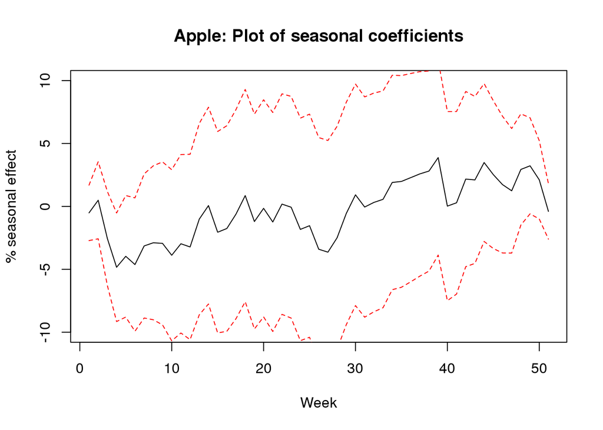

```r
seas.mid=lApple.mod2$coef[6:56]
seas.err=(diag(lApple.mod2$var.coef)**0.5)[6:56]
tcrit=2
seas.high=seas.mid+tcrit*seas.err
seas.low=seas.mid-tcrit*seas.err
plot(seas.mid*100,type='l',
     main='Apple: Plot of seasonal coefficients',
     xlab='Week',ylab='% seasonal effect',
     ylim=c(-10,10))
lines(seas.high*100,lty=2,col='red')
lines(seas.low*100,lty=2,col='red')
```

```r
rm(list=c('tcrit','seas.low','seas.mid','seas.high','seas.err'))
```

The confidence band is chosen for $t_{\mathrm{crit}}=2$. Rarely does the confidence band leave the zero line at all. Hence the seasonal dummies are not significant. We would not have chosen this model if not for the first sentence of the project requirement which mentions seasonal dummies.

*(c) Plot the respective residuals vs. fitted values and discuss your observations.*

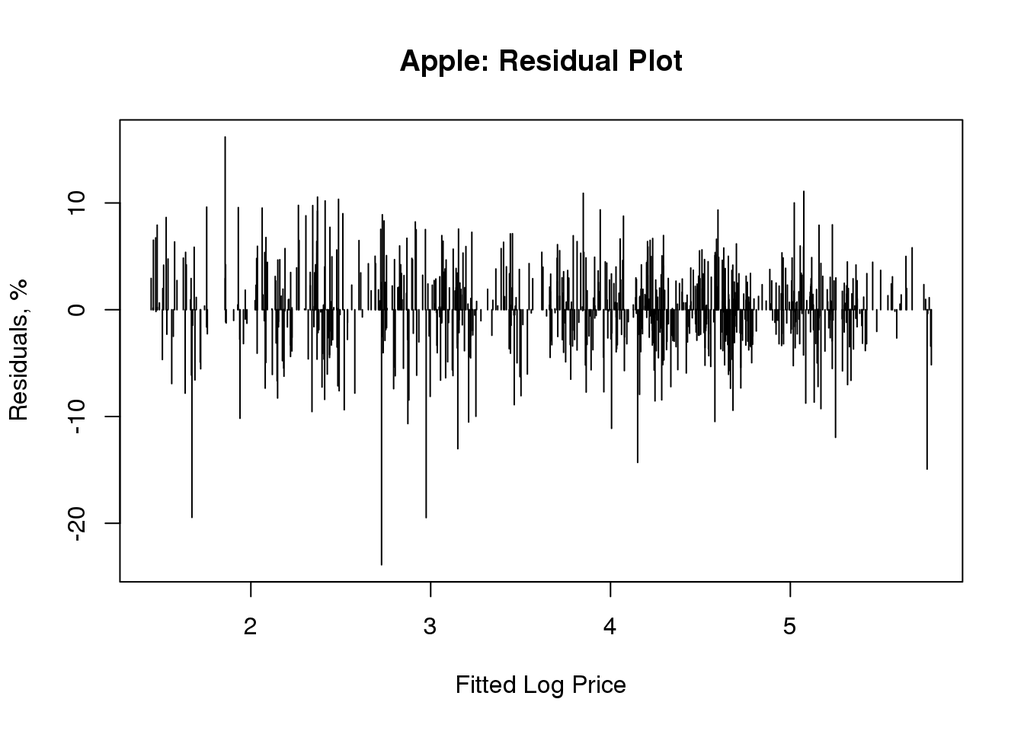

```r
plot(lApple.mod2$fit,lApple.mod2$res*100,type='h',
     main='Apple: Residual Plot',xlab='Fitted Log Price',ylab='Residuals, %')
```

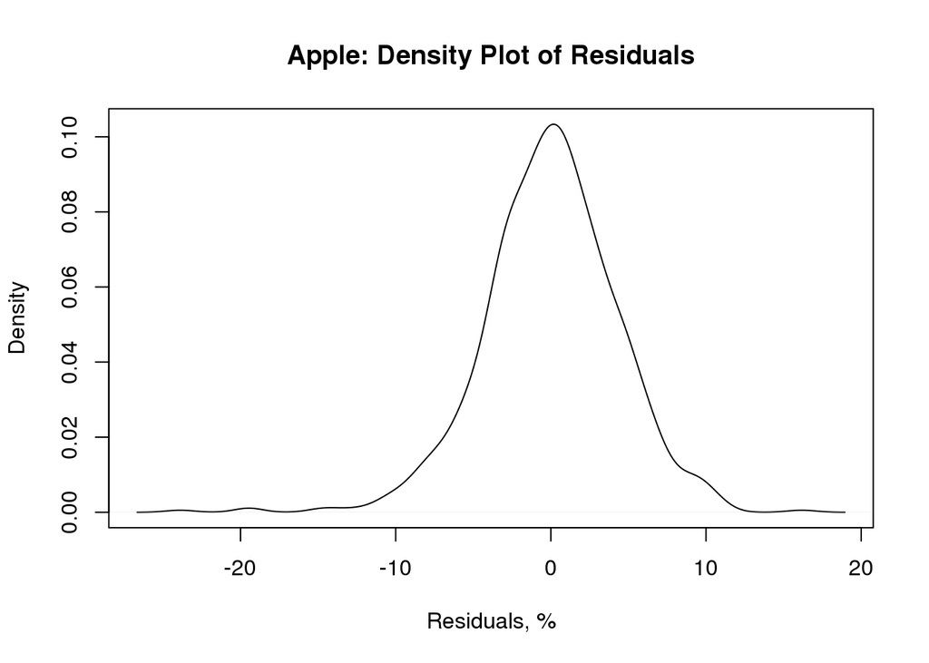

```r
plot(density(lApple.mod2$res*100),main='Apple: Density Plot of Residuals',xlab='Residuals, %')
```

The residuals seems to be homoskedastic and normaly distributed.

*(e) Plot the ACF and PACF of the respective residuals and interpret the plots.*

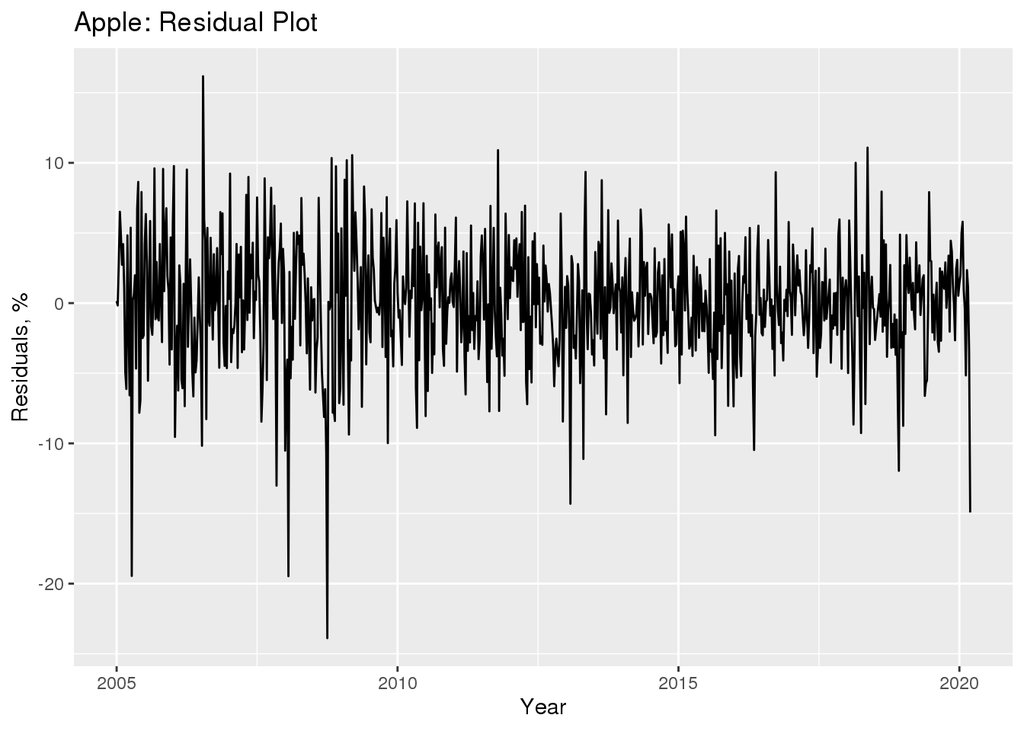

```r
autoplot(lApple.mod2$res*100,
     main='Apple: Residual Plot',xlab='Year',ylab='Residuals, %')
```

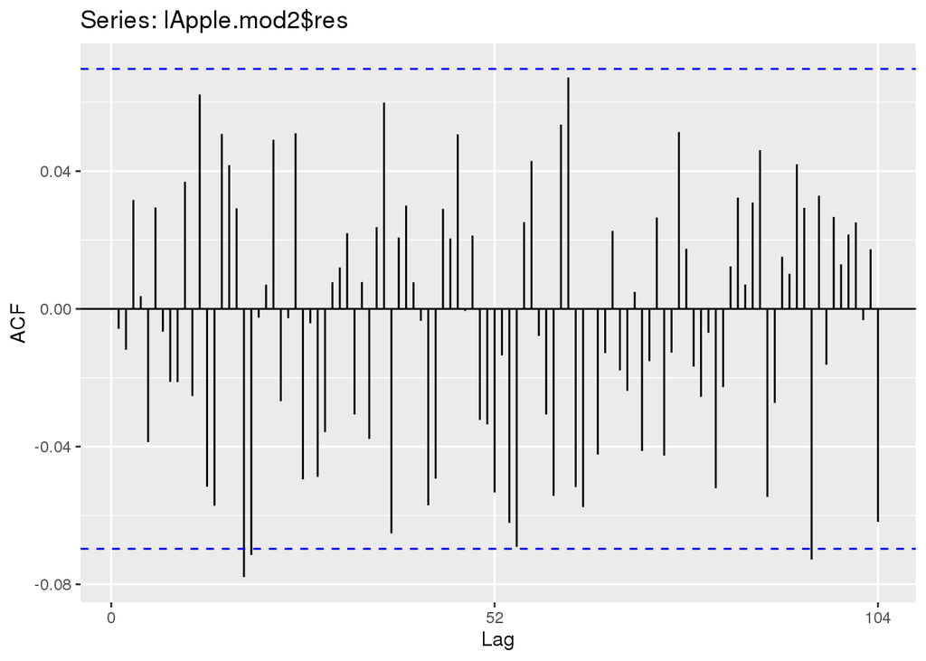

```r
ggAcf(lApple.mod2$res)
```

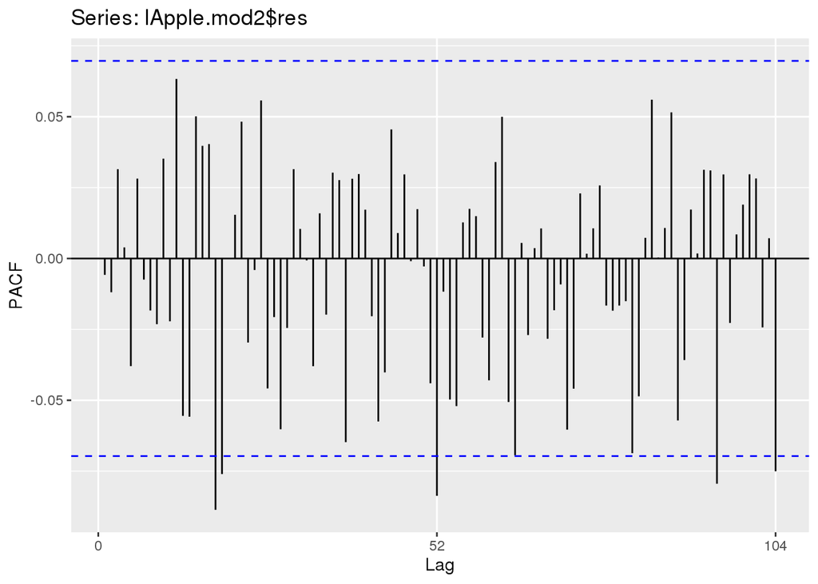

```r
ggPacf(lApple.mod2$res)
```

*(f) Plot the respective CUSUM and interpret the plot.*

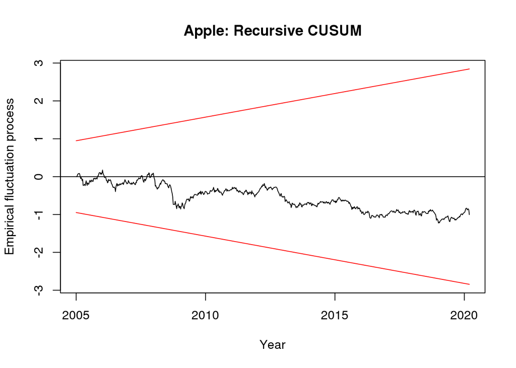

```r
plot(efp(lApple.mod2$res~1, type = "Rec-CUSUM"),main='Apple: Recursive CUSUM', xlab='Year')
```

In 2008 there is a deflection in the recursive CUSUM plot, indicating a mild breakdown of the model in the prediction. In general the level of CUSUM fluctuation as not exceeded the significance band to cause alarm. There remains some information from cycles in the CUSOM plot.

*(g) Plot the respective Recursive Residuals and interpret the plot.*

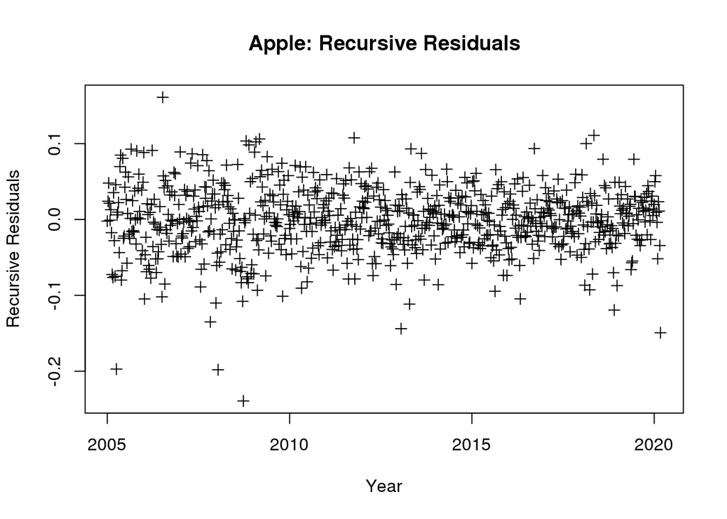

```r
plot(time(lApple),recresid(lApple.mod2$res~1)[1:791], pch=3,
     xlab="Year",ylab="Recursive Residuals",
     main='Apple: Recursive Residuals')
```

We see more fluctuations and outliers in the early years in the data than later, again indicating there could be heteroskedasticity. In general, the model behaves well across the years, as can be seen in the rather uniform distribution of the residuals.

*(h) For your model, discuss the associated diagnostic statistics.*

```r
accuracy(lApple.mod2)
```

```
##                         ME      RMSE        MAE         MPE     MAPE       MASE
## Training set -1.879321e-05 0.0430704 0.03266813 0.004138133 1.017477 0.09139787
##                      ACF1
## Training set -0.005770246
```

The appropriate statistic to look at is the MAE. For log prices, the MAE approximately reflects the average percent deviation of fitted values from observed values, just like MAPE would for non-logged data. Here we see that $MAE=3.27%$. The RMSE reflects a similar percentage. The percent errors reported here are meaningless because the absolute value of the logged data is meaningless.

*(i) Use your model to forecast 12-steps ahead. Your forecast should include the respective error bands.*

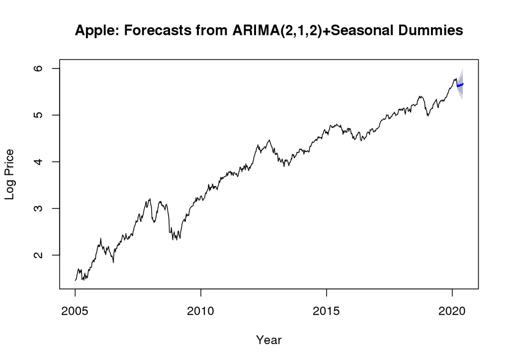

```r
newDummy=seasonaldummy(ts(seq(1:12),start=2020.192+1/52,freq=52))
plot(forecast(lApple.mod2,h=12,xreg=newDummy),
     main='Apple: Forecasts from ARIMA(2,1,2)+Seasonal Dummies',
     xlab='Year', ylab='Log Price')
```

*(j) Compare your forecast from (i) to the 12-steps ahead forecasts from ARIMA, Holt-Winters, and ETS models. Which model performs best in terms of MAPE?*

```r
lApple.train=window(lApple,end=c(2019,51))
lApple.test=window(lApple,start=c(2019,52))

lApple.tsc=Arima(lApple.train,order=c(2,1,2),include.drift=T,xreg=seasonaldummy(lApple.train))
lApple.arima=auto.arima(lApple.train,seasonal=F,d=1,max.p=2,max.q=2) # restricted the order using the results from an unrestricted run.
lApple.hw=HoltWinters(lApple.train)
suppressWarnings(lApple.ets<-ets(lApple.train))
```

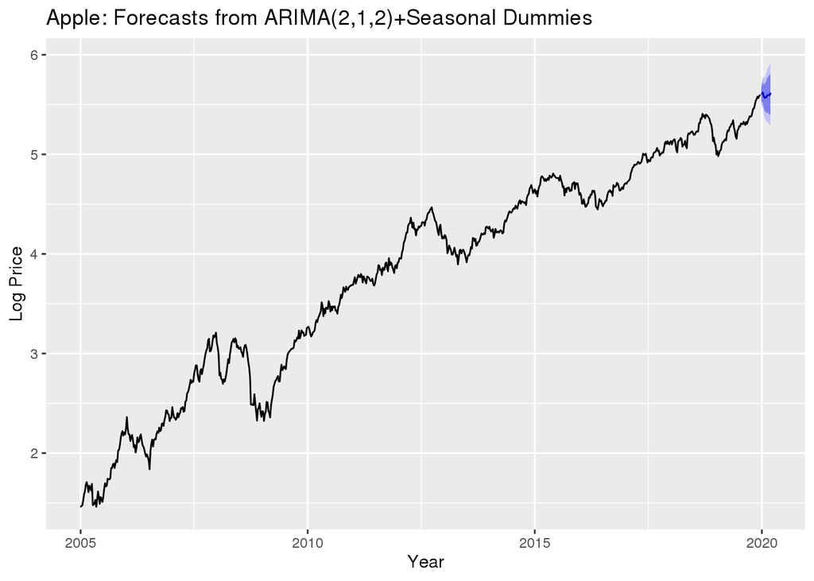

```r
# calculating Apple forecasts under 4 models
lApple.tsc.f=forecast(lApple.tsc,h=12,xreg=seasonaldummy(lApple.test))
lApple.arima.f=forecast(lApple.arima,h=12)
lApple.hw.f=forecast(lApple.hw,h=12)
lApple.ets.f=forecast(lApple.ets,h=12)
autoplot(lApple.tsc.f,
     main='Apple: Forecasts from ARIMA(2,1,2)+Seasonal Dummies',
     xlab='Year', ylab='Log Price')
```

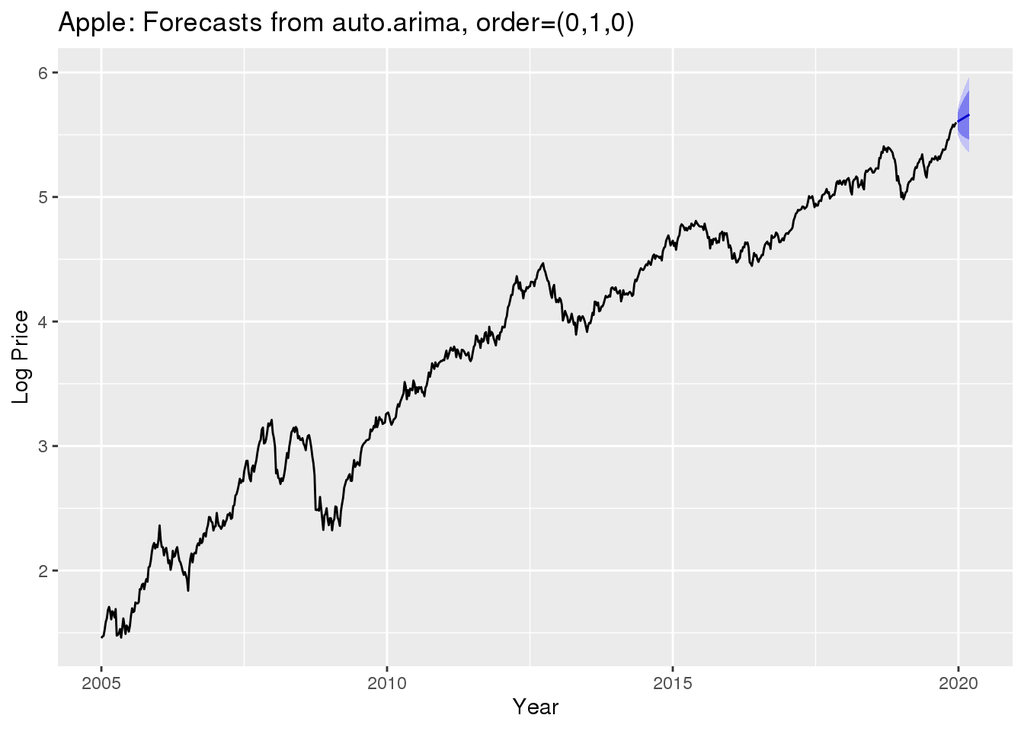

```r
autoplot(lApple.arima.f,
     main='Apple: Forecasts from auto.arima, order=(0,1,0)',
     xlab='Year', ylab='Log Price')
```

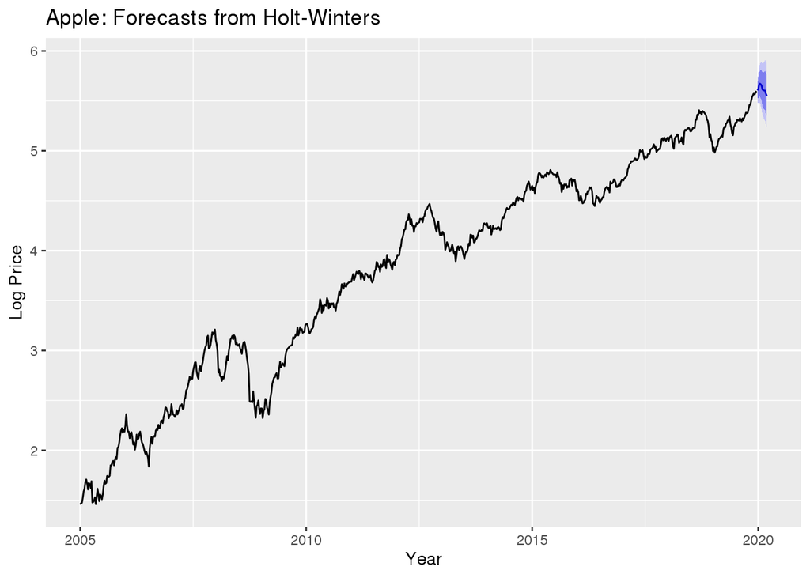

```r
autoplot(lApple.hw.f,
     main='Apple: Forecasts from Holt-Winters',
     xlab='Year', ylab='Log Price')
```

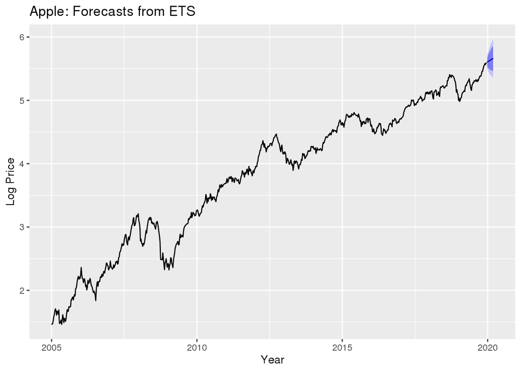

```r
autoplot(lApple.ets.f,
     main='Apple: Forecasts from ETS',
     xlab='Year', ylab='Log Price')
```

```r
# Calculating MAPE
lApple.tsc.MAPE=100*mean(abs(lApple.tsc.f[4]$mean-lApple.test))
lApple.arima.MAPE=100*mean(abs(lApple.arima.f[4]$mean-lApple.test))
lApple.hw.MAPE=100*mean(abs(lApple.hw.f[4]$mean-lApple.test))
lApple.ets.MAPE=100*mean(abs(lApple.ets.f[2]$mean-lApple.test))
print(lApple.tsc.MAPE)
```

```
## [1] 11.49114
```

```r
print(lApple.arima.MAPE)
```

```
## [1] 8.383136
```

```r
print(lApple.hw.MAPE)
```

```
## [1] 9.012791
```

```r
print(lApple.ets.MAPE)
```

```
## [1] 8.332966
```

Because we are using the logged data, the MAPE are calculated as if we are calculating MAE. ETS performs best than the other three models because it has the lowest MAPE.

*(k) Combine the four forecasts and comment on the MAPE from this forecasts vs., the individual ones.*

```r
# combining the forecasts
lApple.combine.f=lm(lApple.test~lApple.tsc.f[4]$mean+lApple.arima.f[4]$mean+lApple.hw.f[4]$mean+lApple.ets.f[2]$mean)$fit
lApple.combine.MAPE=100*mean(abs(lApple.combine.f-lApple.test))
print(lApple.combine.MAPE)
```

```
## [1] 2.383721
```

*The combined model has a significantly lower MAPE than any of the four models by themselves.*

*(l) Fit an appropriate VAR model using your two variables. Make sure to show the relevant plots and discuss your results from the fit.*

*(m) Compute, plot, and interpret the respective impulse response functions.*

*(n) Perform a Granger-Causality test on your variables and discuss your results from the test.*

*(o) Use your VAR model to forecast 12-steps ahead. Your forecast should include the respective error bands. Comment on the differences between the VAR forecast and the other ones obtained using the different methods.*

*(p) Fit a GARCH model to the residuals from your favorite model, and produce a new 12-steps ahead forecast, including one for the variance.*

#III. (5%) Conclusions and Future Work.

#V. (5%) R Source code. Although the code is only worth 5%, if you do not submit your code, you will not receive credit for the assignment.